# Tuesday Analysis

John Clements and Jingjing Li

7/1/2021

# Introduction

Our data set contains daily bike rental counts, information about the weather on a given day, when the day was (date, season, month, and year), and whether the day was a holiday or working day for the Capital Bikeshare system in Washington D.C. in 2011 and 2012. We want to predict the number of rentals on a given weekday (here Tuesday).

We will make our predictions using the weather variables, the season, and the year. The weather related variables are `temp` (normalized temperature), `hum` (normalized humidity), `windspeed` (normalized wind speed), and `weathersit`. The variable `weathersit` is a factor going from 1 to 4, with 1 being nice weather and progressing to 4, which covers severe weather conditions. The `season` variable is a factor for the four seasons, and `yr` is the year. A more in depth description of the data is located here.

To perform our analysis, we will:

- load in the required packages
- read in the data and subset for Tuesdays and split into training and testings sets
- do exploratory analysis through summary statistics and data visualization
- evaluate models in repeated k-folds cross-validation (CV)
- evaluate the models on the withheld testing data

Now let’s get started by reading in loading the required packages.

```r
library(readr)
library(tidyverse)
library(cowplot)
library(caret)
library(rmarkdown)
```

# Reading in and Subsetting the Data

Before doing any analysis, we need to read in the daily bike-share data and subset for all the Tuesdays in the data set.

```r
# Read in the daily data set.
bikeDay <- read_csv("./Bike-Sharing-Dataset/day.csv")
bikeDay <- filter(bikeDay, weekday == params$weekday)
```

Some of the variables, namely, `season`, `mnth`, `holiday`, `workingday`, and `weathersit` are categorical, but are stored numerically. Before proceeding with the analysis, we are converting them to `factor` data types.

```r
# Convert categorical variables stored numerically to factors.
bikeDay <- bikeDay %>%
  mutate(season = factor(ifelse(season == 1, "Spring",
                                ifelse(season == 2, "Summer",
                                       ifelse(season == 3, "Fall",
                                              "Winter"))),
                         levels=c("Spring", "Summer", "Fall", "Winter")),
         mnth = factor(mnth, levels=1:12),
         holiday = factor(holiday, levels=c(0, 1)),
         workingday = factor(workingday, levels=c(0, 1)),
         weathersit = ordered(weathersit, levels=c(1, 2, 3, 4))
         )
```

With that done, we can split the two data sets into training and testing sets for predictive modeling.

```r
# Set a random seed for reproducibility.
set.seed(10)

# Set the proportion of observations to use for training models.
trainProp <- 0.7

# Get indexes for the training and testing subsets of the daily data.
trainIndexes <- sample(1:nrow(bikeDay),
                          size=nrow(bikeDay)*trainProp)
testIndexes <- setdiff(1:nrow(bikeDay), trainIndexes)
# Use the indexes to separate the training and testing sets of the daily data.
bikeTrain <- bikeDay[trainIndexes, ]
bikeTest <- bikeDay[testIndexes, ]
```

With our data sets created, we can now begin exploring the data.

# Data Exploration

Let’s begin our exploration with a histogram of the number of bike rentals in a day for all the Tuesdays in the data to get an idea of the distribution.

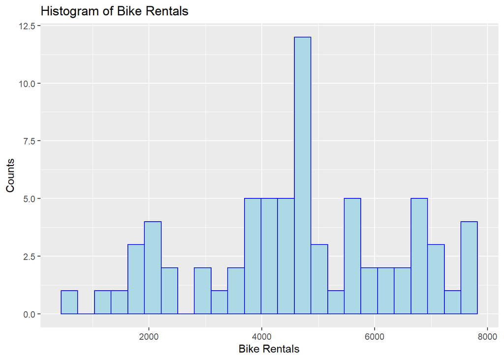

```r
# Create a histogram of bike rentals in a day.
plot1 <- ggplot(bikeTrain, aes(x=cnt)) +
  geom_histogram(bins=25, color="blue", fill="lightblue") +
  xlab("Bike Rentals") +
  ylab("Counts") +
  ggtitle("Histogram of Bike Rentals")

plot1
```

Next, let’s examine the numeric variables related to weather: temperature, humidity, and wind speed. Below are the means and standard deviations for each of these variables by season.

```r
# Find the means and standard deviations of temperature, humidity and windspeed
# by season.
seasonalSummary <- bikeTrain %>%
  group_by(season) %>%
  summarise(
    avgtemp = mean(temp*41), sdtemp = sd(temp*41),
    avghum = mean(hum*100), sdhum = sd(hum*100),
    avgwindspd = mean(windspeed*67), sdwindspd=sd(windspeed*67)
    )

# Print out the table.
knitr::kable(
  seasonalSummary,
  col.names=c("Season",
              "Temp. Mean", "Temp. Std. Dev.",
              "Humidity Mean", "Humidity Std. Dev.",
              "Wind Speed Mean", "Wind Speed Std. Dev."),
  digits=2,
  caption=paste0("Table 1: Means and Standard Deviations for Daily Temp. ",
                 "(Celsius), Humidity, and Wind Speed (km/h)")
)
```

Table 1: Means and Standard Deviations for Daily Temp. (Celsius), Humidity, and Wind Speed (km/h)

| Season | Temp. Mean | Temp. Std. Dev. | Humidity Mean | Humidity Std. Dev. | Wind Speed Mean | Wind Speed Std. Dev. |
| --- | --- | --- | --- | --- | --- | --- |
| Spring | 12.06 | 4.03 | 57.14 | 15.23 | 13.93 | 5.23 |
| Summer | 24.02 | 5.09 | 62.77 | 14.54 | 16.37 | 5.28 |
| Fall | 29.28 | 2.63 | 61.94 | 10.66 | 11.16 | 4.15 |
| Winter | 18.59 | 4.22 | 69.76 | 10.35 | 11.22 | 4.51 |

The box plots below gives a better sense of the distributions of these variables by season, than just the two summary statistics.

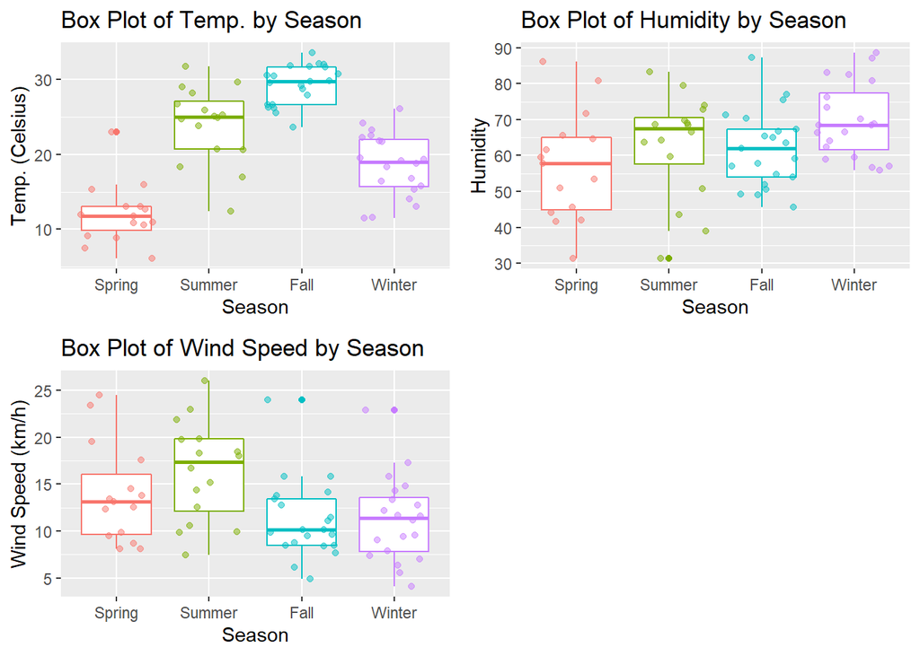

```r
###
# Create boxplots of the variables mentioned above, grouped by season.
###

plot2 <- ggplot(bikeTrain, aes(x=season, y=temp*41, color=season)) +
  geom_boxplot() +
  geom_jitter(alpha=0.5) +
  labs(x="Season",
       y="Temp. (Celsius)",
       title="Box Plot of Temp. by Season") +
  theme(legend.position="none")

plot3 <- ggplot(bikeTrain, aes(x=season, y=hum*100, color=season)) +
  geom_boxplot() +
  geom_jitter(alpha=0.5) +
  labs(x="Season",
       y="Humidity",
       title="Box Plot of Humidity by Season") +
  theme(legend.position="none")

plot4 <- ggplot(bikeTrain, aes(x=season, y=windspeed*67,
                                        color=season)) +
  geom_boxplot() +
  geom_jitter(alpha=0.5) +
  labs(x="Season",
       y="Wind Speed (km/h)",
       title="Box Plot of Wind Speed by Season") +
  theme(legend.position="none")

plot_grid(plot2, plot3, plot4)
```

Now let’s examine the counts of weather situation by season.

```r
# Compare weather situation counts for the four seasons.
seasonWeather <- table(bikeTrain$season, bikeTrain$weathersit)

# Display the table.
knitr::kable(
  seasonWeather,
  col.names=c("Pleasant", "Overcast", "Unpleasant", "Severe"),
  caption="Table 2: Weather Situation by Season"
)
```

Table 2: Weather Situation by Season

|  | Pleasant | Overcast | Unpleasant | Severe |
| --- | --- | --- | --- | --- |
| Spring | 10 | 5 | 0 | 0 |
| Summer | 9 | 7 | 0 | 0 |
| Fall | 18 | 3 | 0 | 0 |
| Winter | 9 | 10 | 1 | 0 |

Although the relationships between seasons and numeric weather measures are interesting, we want to predict bike rentals. So now we look at how our numeric weather measures and seasons relate to bike rentals.

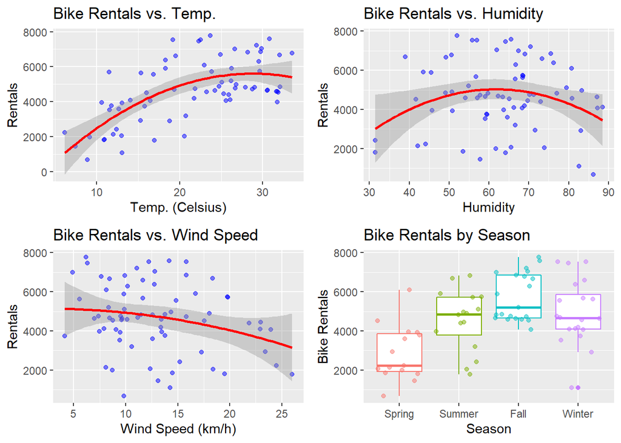

```r
###
# Create scatter plots for bike rentals vs. our numeric variables and box plots
# for bike rentals by season.
###

plot5 <- ggplot(bikeTrain, aes(x=temp*41, y=cnt)) +
  geom_point(color="blue", alpha=0.5) +
  geom_smooth(method = 'lm', formula='y ~ poly(x, 2)', color="red") +
  xlab("Temp. (Celsius)") +
  ylab("Rentals") +
  ggtitle("Bike Rentals vs. Temp.")

plot6 <- ggplot(bikeTrain, aes(x=hum*100, y=cnt)) +
  geom_point(color="blue", alpha=0.5) +
  geom_smooth(method = 'lm', formula='y ~ poly(x, 2)', color="red") +
  xlab("Humidity") +
  ylab("Rentals") +
  ggtitle("Bike Rentals vs. Humidity")

plot7<- ggplot(bikeTrain, aes(x=windspeed*67, y=cnt)) +
  geom_point(color="blue", alpha=0.5) +
  geom_smooth(method = 'lm', formula='y ~ poly(x, 2)', color="red") +
  xlab("Wind Speed (km/h)") +
  ylab("Rentals") +
  ggtitle("Bike Rentals vs. Wind Speed")

plot8 <- ggplot(bikeTrain, aes(x=season, y=cnt, color=season)) +
  geom_boxplot() +
  geom_jitter(alpha=0.5) +
  xlab("Season") +
  ylab("Bike Rentals") +
  ggtitle("Bike Rentals by Season") +
  theme(legend.position="none")

plot_grid(plot5, plot6, plot7, plot8)
```

Finally, let’s examine the distributions of bike rentals by weather situation and year.

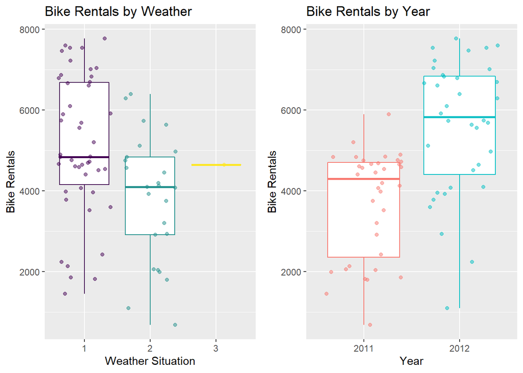

```r
###
# Create box plots of bike rentals by weather situation and year.
###

plot9 <- ggplot(bikeTrain, aes(x=weathersit, y=cnt,
                                        color=weathersit)) +
  geom_boxplot() +
  geom_jitter(alpha=0.5) +
  xlab("Weather Situation") +
  ylab("Bike Rentals") +
  ggtitle("Bike Rentals by Weather") +
  theme(legend.position="none")

plot10 <- ggplot(bikeTrain, aes(as.factor(yr+2011), cnt,
                                color=as.factor(yr+2011))) +
  geom_boxplot() +
  geom_jitter(alpha=0.5) +
  xlab("Year") +
  ylab("Bike Rentals") +
  ggtitle("Bike Rentals by Year") +
  theme(legend.position="none")

plot_grid(plot9, plot10)
```

We now have an idea of how our predictive features relate to the number of bike rentals, so we are ready to move onto modeling.

# Modeling

We want to predict bike rental demand in a given day conditional on weather-related variables, the season, and the year. These can be known *a priori* (assuming a weather forecast for the next day is fairly accurate). We will try linear and ensemble modeling approaches.

```r
# Set the parameters for repeated k-folds CV.
k <- 5
repeats <- 3

# Create a trainControl object for repeated k-folds CV.
trCntrl <- trainControl(method="repeatedcv", number=k, repeats=repeats)
```

We are doing 5-folds CV with 3 repeats.

## Linear models

### Linear Model 1 (OLS)

For our first model, we are assuming the number of bike rentals has quadratic relationships with temperature, wind speed, and humidity, with seasonal effects, and a linear trend for year. The linear trend of year will probably perform particularly poorly for extrapolation. As the bike rental company is around longer, their rate of yearly growth will decrease as they approach market saturation. The model is shown below.

$\text{# of rentals}_i = \beta_0 + \beta_1\text{temp}_i + \beta_2\text{temp}_i^2 + \beta_3\text{wind speed}_i + \beta_4\text{wind speed}_i^2 + \beta_5\text{humidity}_i + \beta_6\text{humidity}_i^2 + \beta_7\text{Summer}_i +\beta_8\text{Fall}_i + \beta_9\text{Winter}_i + \beta_{10}\text{year}_i + \epsilon_i$

where $\epsilon_i \overset{\text{iid}}\sim \text{N}(0, \sigma^2)$.

Thus, our model for the distribution of bike rentals in a day for Tuesday is:

$$\text{# of rentals}_i \overset{iid}\sim \text{N}(\mu_i = \beta_0 + \Sigma_{j=1}^{10}\beta_ix_i, \text{ } \sigma^2)$$

where $x_i$ is the $i^{th}$ variable in the regression model.

We will refer to this model as the **OLS** model.

```r
# Evaluate a linear model of the specified form in repeated k-folds CV and fit
# it to the training set.
linMod1 <- train(
  cnt ~ temp + I(temp^2) + windspeed + I(windspeed^2) + hum + I(hum^2)
  + season + yr,
  data=bikeTrain,
  method="lm",
  trControl=trCntrl
  )
```

### Linear Model 2 (Poisson Regression)

In our second model, we assume the same combination of variables and any quadratic effects are modeling a poisson process. This assumption is based on bike rentals being a count and our count occurs in a set amount of time (a single day). Our model for the $\lambda$ parameter of the Poisson distribution is:

$\lambda_i = \beta_0 + \beta_1\text{temp}_i + \beta_2\text{temp}_i^2 + \beta_3\text{wind speed}_i + \beta_4\text{wind speed}_i^2 + \beta_5\text{humidity}_i + \beta_6\text{humidity}_i^2 + \beta_7\text{Summer}_i +\beta_8\text{Fall}_i + \beta_9\text{Winter}_i + \beta_{10}\text{year}_i + \epsilon_i$

where $\epsilon_i \overset{\text{iid}}\sim \text{N}(0, \sigma^2)$.

Thus, our model for the distribution of bike rentals in a day for Tuesday is:

$$\text{# of rentals}_i \overset{iid}\sim \text{Poisson}(\lambda_i = \beta_0 + \Sigma_{j=1}^{10}\beta_ix_i)$$

We will refer to this model as the **Poisson Regression** model.

```r
# Evaluate a linear model of the specified form in repeated k-folds CV and fit
# it to the training set.
linMod2 <- train(
  cnt ~ temp + I(temp^2) + windspeed + I(windspeed^2) + hum + I(hum^2)
  + season + yr,
  data=bikeTrain,
  method="glm",
  family="poisson",
  trControl=trCntrl
  )
```

## Ensemble Tree Models

Tree-based ensemble methods are very popular in applied machine learning due to their ability to model non-linear and interaction effects. Here we try the two most popular ensemble methods: random forests and gradient boosted trees. We also perform a grid search in our repeated k-folds CV to tune our models for the best hyper-parameters.

### Random Forest

Random forests create **B** boostrapped samples and fit trees to each of the boostrapped samples. At each split in each tree, only a random subset of variables are considered. Both steps push the trees to grow independently on one another. For regression, the predictions of trees are averaged to get the final predicted value. For classification, the majority vote of class membership is generally used to predict the class.

The combination of pushing the trees to grow independently and averaging should lower the variance of our prediction. Given the mean squared error can be decomposed into the squared bias plus the variance of the model, this will hopefully decrease the MSE (if the reduction in variance is greater than the increase in squared bias).

```r
# Perform the grid search through repeated CV.
rfFit <- train (
  cnt ~ temp + windspeed + hum + season + yr,
  data=select(bikeTrain, -"weekday"),
  method="rf",
  preProcess= c("center", "scale"),
  trControl = trCntrl,
  tuneGrid=expand.grid(mtry=c(100, 500, 1000))
  )
```

### Boosted Trees

Boosting is one of tree based statistical ensemble learning methods for regression or classification. Like other tree based methods, boosted tree involves in splitting predictor space into regions. But it has also some unique features: the tree growth is sequential and slow, which means each tree is modified based on previous one. Three parameters are used to tune boosting process: number of trees B, shrinkage parameter lambda bad split number d which control the complexity of boosted ensembles. Boosted tree tends to decrease bias.

Now we can choose our hyper-parameters through repeated k-folds CV and fit our model, which we refer to as the **Boosted Trees** model.

```r
# Set grid of tuning parameters to try.
gbmGrid <- expand.grid(
  interaction.depth=c(1, 4, 6),
  n.trees=c(100, 500),
  shrinkage=c(0.01, 0.1),
  n.minobsinnode=c(3, 10)
)

# Perform the grid search through repeated CV.
gbmFit <- train (
  cnt ~ temp + windspeed + hum + season + yr,
  data=select(bikeTrain, -"weekday"),
  method="gbm",
  preProcess= c("center", "scale"),
  trControl = trCntrl,
  tuneGrid=gbmGrid
  )
```

## Comparing the Models

With the repeated k-folds CV completed and our models fit, we can evaluate their performance in CV and on the withheld testing set.

Let’s evaluate their repeated k-folds CV performance first.

```r
# Create a list of models and vector of model names.
modelList <- list(linMod1, linMod2, rfFit, gbmFit)
modelNames <- c("OLS", "Poisson Regression", "Random Forest", "Boosted Trees")

###
# Extract model performances and put them in a summary table.
###

cvRMSE <- unlist(
  sapply(
    sapply(
      sapply(modelList, FUN="[", "results"),
      FUN=filter, RMSE==min(RMSE)),
    FUN="[", "RMSE"
    )
  )

cvMAE <- unlist(
  sapply(
    sapply(
      sapply(modelList, FUN="[", "results"),
      FUN=filter, MAE==min(MAE)),
    FUN="[", "MAE"
    )
  )

cvRsquared <- unlist(
  sapply(
    sapply(
      sapply(modelList, FUN="[", "results"),
      FUN=filter, Rsquared==max(Rsquared)),
    FUN="[", "Rsquared"
    )
  )

# Create a data.frame of model performances.
cvPerformance <- data.frame(
  Model=modelNames,
  RMSE=cvRMSE,
  Rsq=cvRsquared,
  MAE=cvMAE
)

# Extract the best model's name and RMSE.
bestModelCV <- cvPerformance %>%
  mutate(Model = modelNames) %>%
  filter(RMSE == min(RMSE)) %>%
  select(Model, RMSE)
# Save the model name and RMSE to 2 decimal places as vairables.
bestModelNameCV <- bestModelCV$Model
bestRMSECV <- round(bestModelCV$RMSE, 2)

# Display the table in a neat format.
knitr::kable(
  cvPerformance,
  digits=2,
  caption="Table 3: Repeated k-folds CV Performance Summary",
  col.names=c("", "RMSE", "Rsquared", "MAE")
)
```

Table 3: Repeated k-folds CV Performance Summary

|  | RMSE | Rsquared | MAE |
| --- | --- | --- | --- |
| OLS | 757.79 | 0.83 | 600.23 |
| Poisson Regression | 644.74 | 0.87 | 501.72 |
| Random Forest | 837.04 | 0.79 | 648.86 |
| Boosted Trees | 653.82 | 0.87 | 502.69 |

The best performing model in repeated k-folds CV is the Poisson Regression with an RMSE of 644.74. Usually, we would pick the best performing model here to test on the testing data, but we will compare them all this time.

Now let’s look at their test set performance.

```r
evaluatePeformance <- function(model, dataEval, target){
  ###
  # This function takes in a fit model, testing data (tibble), and a target
  # variable (string) and returns the performance.
  ###
  preds <- predict(model, newdata=dataEval)
  return(postResample(preds, pull(dataEval, target)))
}

# Get the test set performances.
testPerformances <- sapply(
  modelList, FUN=evaluatePeformance, dataEval=bikeTest, target="cnt"
  )
# Rename the columns with the model names.
colnames(testPerformances) <- modelNames

# Convert the table to data.frame.
testPerformances <- as.data.frame(t(testPerformances))

# Extract the best model's name and RMSE.
bestModel <- testPerformances %>%
  mutate(Model = modelNames) %>%
  filter(RMSE == min(RMSE)) %>%
  select(Model, RMSE)
# Save the model name and RMSE to 2 decimal places as vairables.
bestModelName <- bestModel$Model
bestRMSE <- round(bestModel$RMSE, 2)

# Display the table in a neat format.
knitr::kable(
  testPerformances,
  digits=2,
  caption="Table 4: Test Set Performance Summary",)
```

Table 4: Test Set Performance Summary

|  | RMSE | Rsquared | MAE |
| --- | --- | --- | --- |
| OLS | 845.71 | 0.84 | 681.96 |
| Poisson Regression | 751.89 | 0.86 | 609.47 |
| Random Forest | 948.53 | 0.76 | 730.53 |
| Boosted Trees | 823.44 | 0.82 | 638.08 |

The best performing model on the testing set is the Poisson Regression with an RMSE of 751.89.